# Regression over Multiple Varibles

Derek Sollberger

4/15/2021

```r
# Include packages needed for setup.
library("moderndive")     #for get_correlation() function
library("palmerpenguins") #data set for practice
library("patchwork")      #easily place graphs side-by-side
library("tidyverse")      #suite of packages for data science ease
```

# Recap

- Today’s tutorial is similar to [Chapter 6](https://moderndive.com/6-multiple-regression.html) of the *Statistical Inference* textbook

```r
# https://allisonhorst.github.io/palmerpenguins/
penguins
```

```
## # A tibble: 344 x 8
##    species island    bill_length_mm bill_depth_mm flipper_length_mm body_mass_g
##    <fct>   <fct>              <dbl>         <dbl>             <int>       <int>
##  1 Adelie  Torgersen           39.1          18.7               181        3750
##  2 Adelie  Torgersen           39.5          17.4               186        3800
##  3 Adelie  Torgersen           40.3          18                 195        3250
##  4 Adelie  Torgersen           NA            NA                  NA          NA
##  5 Adelie  Torgersen           36.7          19.3               193        3450
##  6 Adelie  Torgersen           39.3          20.6               190        3650
##  7 Adelie  Torgersen           38.9          17.8               181        3625
##  8 Adelie  Torgersen           39.2          19.6               195        4675
##  9 Adelie  Torgersen           34.1          18.1               193        3475
## 10 Adelie  Torgersen           42            20.2               190        4250
## # … with 334 more rows, and 2 more variables: sex <fct>, year <int>
```

```r
# display the column names of the penguin dataset
colnames(penguins)
```

```
## [1] "species"           "island"            "bill_length_mm"
## [4] "bill_depth_mm"     "flipper_length_mm" "body_mass_g"
## [7] "sex"               "year"
```

```r
# structure of the data frame
str(penguins)
```

```
## tibble[,8] [344 × 8] (S3: tbl_df/tbl/data.frame)
##  $ species          : Factor w/ 3 levels "Adelie","Chinstrap",..: 1 1 1 1 1 1 1 1 1 1 ...
##  $ island           : Factor w/ 3 levels "Biscoe","Dream",..: 3 3 3 3 3 3 3 3 3 3 ...
##  $ bill_length_mm   : num [1:344] 39.1 39.5 40.3 NA 36.7 39.3 38.9 39.2 34.1 42 ...
##  $ bill_depth_mm    : num [1:344] 18.7 17.4 18 NA 19.3 20.6 17.8 19.6 18.1 20.2 ...
##  $ flipper_length_mm: int [1:344] 181 186 195 NA 193 190 181 195 193 190 ...
##  $ body_mass_g      : int [1:344] 3750 3800 3250 NA 3450 3650 3625 4675 3475 4250 ...
##  $ sex              : Factor w/ 2 levels "female","male": 2 1 1 NA 1 2 1 2 NA NA ...
##  $ year             : int [1:344] 2007 2007 2007 2007 2007 2007 2007 2007 2007 2007 ...
```

```r
# calculate a linear model based on the body mass of the penguins
one_num_var_model <- lm(flipper_length_mm ~ body_mass_g, data = penguins)
```

```r
# calculate a linear model based on the species of the penguins
one_cat_var_model <- lm(flipper_length_mm ~ species, data = penguins)
```

$$\hat{\text{flipper_length}} = b_{0} + b_{Chin} \cdot \vec{1}_{Chin} + b_{Gent} \cdot \vec{1}_{Gent}$$

```r
indicator_df <- penguins %>%
  mutate(Adelie_ind    = ifelse(species == "Adelie",    1, 0),
         Chinstrap_ind = ifelse(species == "Chinstrap", 1, 0),
         Gentoo_ind    = ifelse(species == "Gentoo",    1, 0)) %>%
  select(species, Adelie_ind, Chinstrap_ind, Gentoo_ind)
```

$$\vec{1}_{Chin} = \begin{cases}
1 & \text{if penguin is of Chinstrap species} \\
0 & \text{if penguin is not a Chinstrap}
\end{cases}$$

# Multiple Regression

## One numerical and one categorical variable

```r
# note where the plus sign (+) is
parallel_slopes_model <- lm(flipper_length_mm ~ body_mass_g + species, data = penguins)
```

```r
# display the model's data
parallel_slopes_model
```

```
##
## Call:
## lm(formula = flipper_length_mm ~ body_mass_g + species, data = penguins)
##
## Coefficients:
##      (Intercept)       body_mass_g  speciesChinstrap     speciesGentoo
##        1.589e+02         8.402e-03         5.597e+00         1.568e+01
```

```r
# display the regression table of the parallel slopes model
get_regression_table(parallel_slopes_model)
```

```
## # A tibble: 4 x 7
##   term             estimate std_error statistic p_value lower_ci upper_ci
##   <chr>               <dbl>     <dbl>     <dbl>   <dbl>    <dbl>    <dbl>
## 1 intercept         159.        2.39      66.6        0  154.      164.
## 2 body_mass_g         0.008     0.001     13.3        0    0.007     0.01
## 3 speciesChinstrap    5.60      0.788      7.10       0    4.05      7.15
## 4 speciesGentoo      15.7       1.09      14.4        0   13.5      17.8
```

## Parallel slopes

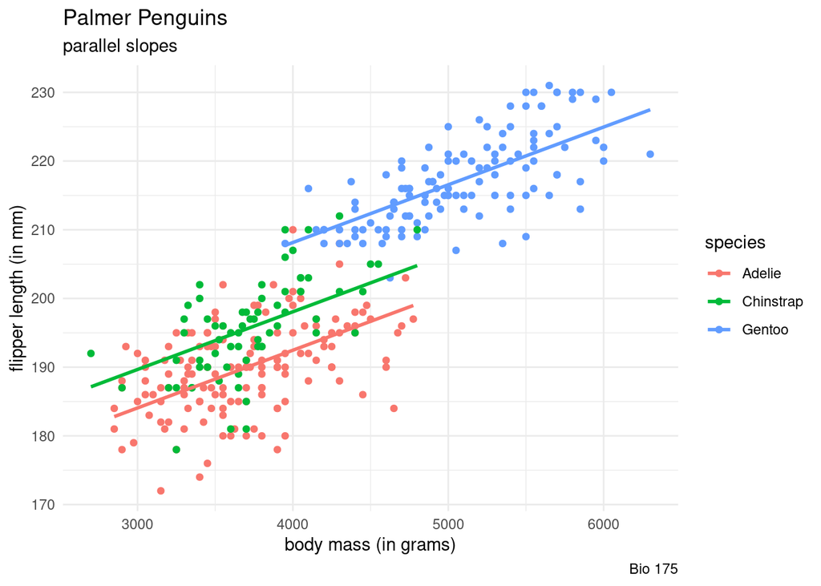

```r
# graph all the different species of penguins with their best fit lines together. Set parallel slopes to false
parallel_slopes_viz <- penguins %>%
  ggplot(aes(x = body_mass_g, y = flipper_length_mm,
             color = species, group = species)) +
  geom_point() +
  geom_parallel_slopes(se = FALSE) + #function from moderndive package
  labs(title = "Palmer Penguins",
       subtitle = "parallel slopes",
       caption = "Bio 175",
       x = "body mass (in grams)",
       y = "flipper length (in mm)") +
  theme_minimal()

parallel_slopes_viz
```

```r
# build a linear model based on the summation of the body mass and the species data
parallel_slopes_model <- lm(flipper_length_mm ~ body_mass_g + species, data = penguins)
```

$$\hat{\text{flipper_length}} = b_{0} + b_{mass} \cdot \text{mass} + b_{Chin} \cdot \vec{1}_{Chin} + b_{Gent} \cdot \vec{1}_{Gent}$$

For an Adelie penguin

$$\hat{\text{flipper_length}} = b_{0} + b_{mass} \cdot \text{mass}$$
$$\hat{\text{flipper_length}} = 158.860 + 0.008 \cdot \text{mass}$$

For a Chinstrap penguin

$$\hat{\text{flipper_length}} = b_{0} + b_{mass} \cdot \text{mass} + b_{Chin}$$
$$\hat{\text{flipper_length}} = 158.860 + 0.008 \cdot \text{mass} + 5.597$$

For a Gentoo penguin

$$\hat{\text{flipper_length}} = b_{0} + b_{mass} \cdot \text{mass} + b_{Gent}$$
$$\hat{\text{flipper_length}} = 158.860 + 0.008 \cdot \text{mass} + 15.677$$

## Interaction terms

```r
# note the use of the multiplication symbol (*) between the explanatory variables
interaction_model <- lm(flipper_length_mm ~ body_mass_g * species, data = penguins)
```

```r
# display the regression data in a table from the interaction model
get_regression_table(interaction_model)
```

```
## # A tibble: 6 x 7
##   term                    estimate std_error statistic p_value lower_ci upper_ci
##   <chr>                      <dbl>     <dbl>     <dbl>   <dbl>    <dbl>    <dbl>
## 1 intercept                165.        3.55      46.5    0      158.     172.
## 2 body_mass_g                0.007     0.001      7.01   0        0.005    0.009
## 3 speciesChinstrap         -13.9       7.30      -1.90   0.058  -28.2      0.498
## 4 speciesGentoo              6.06      6.05       1.00   0.317   -5.84    18.0
## 5 body_mass_g:speciesChi…    0.005     0.002      2.68   0.008    0.001    0.009
## 6 body_mass_g:speciesGen…    0.002     0.001      1.75   0.082    0        0.005
```

$$\hat{\text{flipper_length}} = b_{0} + b_{mass} \cdot \text{mass} + b_{Chin} \cdot \vec{1}_{Chin} + b_{Gent} \cdot \vec{1}_{Gent} + b_{mass,Chin} \cdot \vec{1}_{Chin} \cdot \text{mass} + b_{mass,Gent} \cdot \vec{1}_{Gent} \cdot \text{mass}$$

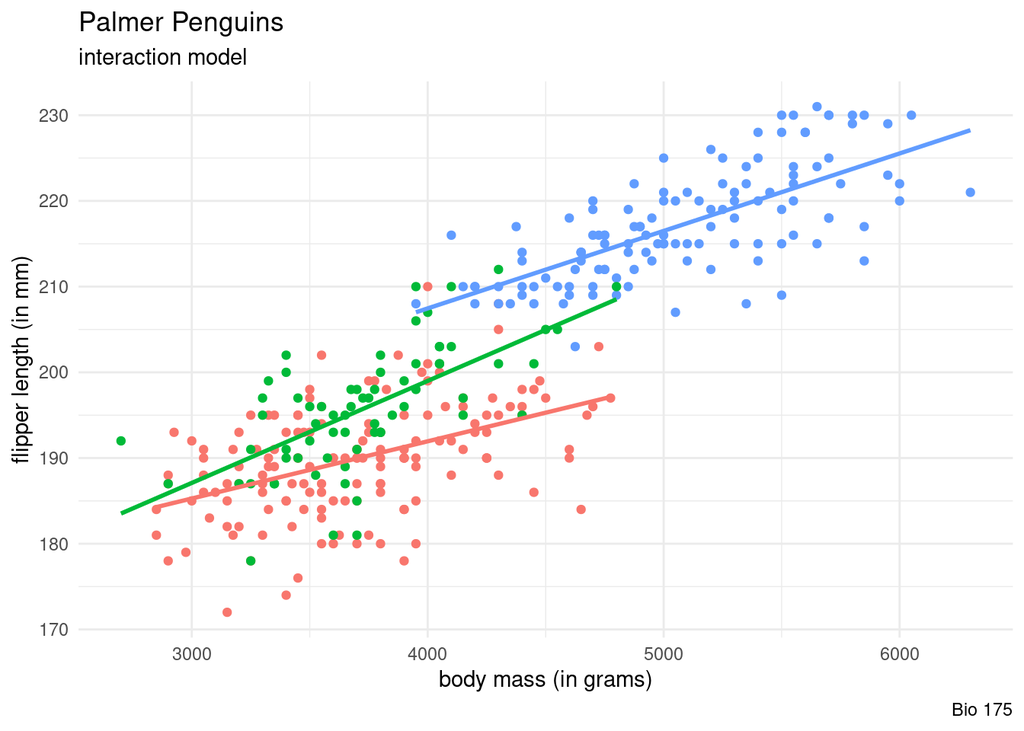

```r
# graph all the different species of penguins with their best fit lines together. Set method to linear model
interaction_model_viz <- penguins %>%
  ggplot(aes(x = body_mass_g, y = flipper_length_mm,
             color = species, group = species)) +
  geom_point() +
  geom_smooth(method = "lm", se = FALSE) +
  labs(title = "Palmer Penguins",
       subtitle = "interaction model",
       caption = "Bio 175",
       x = "body mass (in grams)",
       y = "flipper length (in mm)") +
  theme_minimal() +
  theme(legend.position = "none")

interaction_model_viz
```

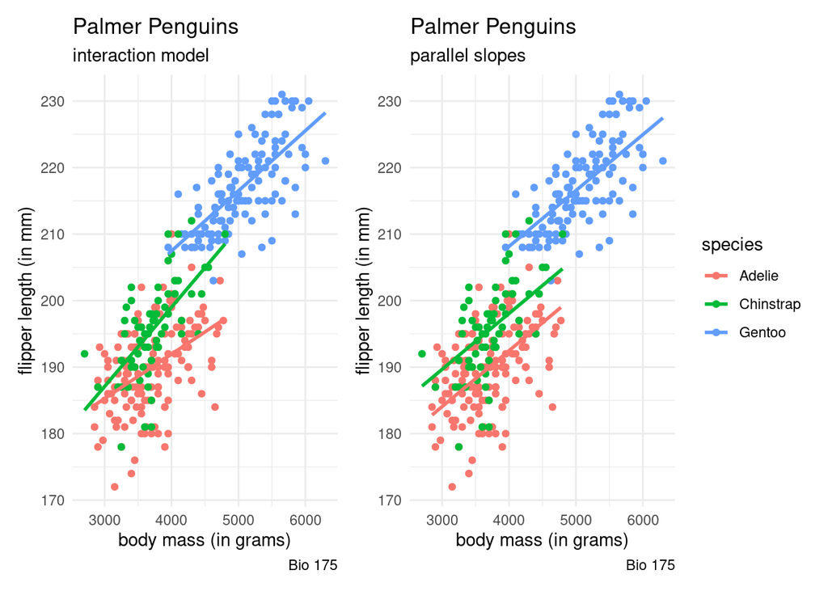

```r
# show both the interaction model and the parallel slopes side by side
interaction_model_viz + parallel_slopes_viz
```

For an Adelie penguin

$$\hat{\text{flipper_length}} = b_{0} + b_{mass} \cdot \text{mass}$$
$$\hat{\text{flipper_length}} = 165.245 + 0.007 \cdot \text{mass}$$
For a Chinstrap penguin

$$\hat{\text{flipper_length}} = b_{0} + b_{mass} \cdot \text{mass} + b_{Chin} + b_{mass,Chin} \cdot \text{mass}$$
$$\begin{array}{rcl}
\hat{\text{flipper_length}} & = & 165.245 + 0.007 \cdot \text{mass} - 13.864 + 0.005 \cdot \text{mass} \\
~ & = & (165.245 - 13.864) + (0.007 + 0.005) \cdot \text{mass} \\
\end{array}$$

For a Gentoo penguin

$$\hat{\text{flipper_length}} = b_{0} + b_{mass} \cdot \text{mass} + b_{Gent} + b_{mass,Gent} \cdot \text{mass}$$
$$\begin{array}{rcl}
\hat{\text{flipper_length}} & = & 165.245 + 0.007 \cdot \text{mass} + 6.059 + 0.002 \cdot \text{mass} \\
~ & = & (165.245 + 6.059) + (0.007 + 0.002) \cdot \text{mass} \\
\end{array}$$

# Multiple Numerical Variables

```r
# calculate a linear model of the summation of bill length, bill depth, and body mass
multi_num_var_model <- lm(flipper_length_mm ~ bill_length_mm + bill_depth_mm + body_mass_g,
                          data = penguins)
```

```r
# generate a table of the regression from the new linear model
get_regression_table(multi_num_var_model)
```

```
## # A tibble: 4 x 7
##   term           estimate std_error statistic p_value lower_ci upper_ci
##   <chr>             <dbl>     <dbl>     <dbl>   <dbl>    <dbl>    <dbl>
## 1 intercept       158.        4.63      34.1        0  149.     167.
## 2 bill_length_mm    0.592     0.072      8.26       0    0.451    0.733
## 3 bill_depth_mm    -1.68      0.181     -9.29       0   -2.03    -1.32
## 4 body_mass_g       0.011     0.001     20.3        0    0.01     0.012
```

$$\hat{\text{flipper_length}} = b_{0} + b_{\text{bill_length}} \cdot \text{bill_length} + b_{\text{bill_depth}} \cdot \text{bill_depth} + b_{\text{body_mass}} \cdot \text{body_mass}$$
$$\hat{\text{flipper_length}} = 157.786 + 0.592 \cdot \text{bill_length} - 1.679 \cdot \text{bill_depth} + 0.011 \cdot \text{body_mass}$$

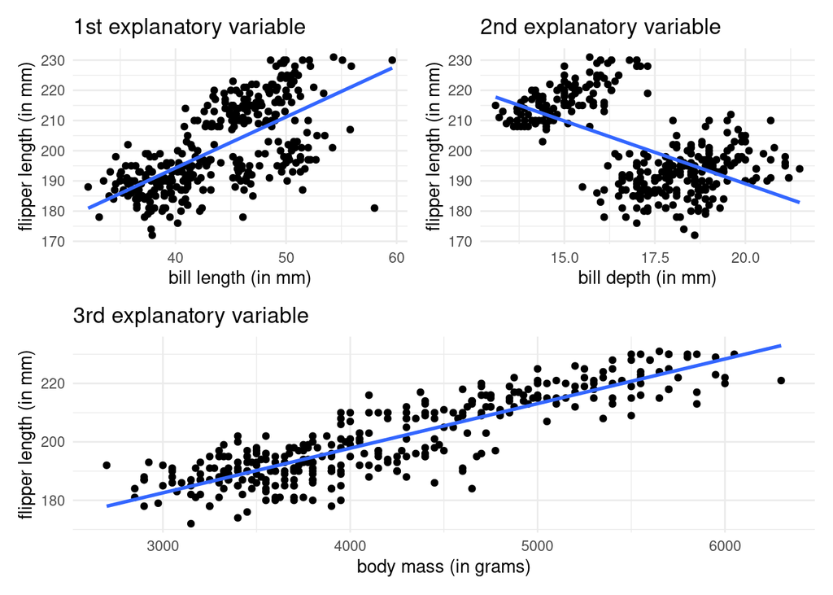

```r
# graph bill length vs. flipper length
multi_num_var_viz1 <- penguins %>%
  ggplot(aes(x = bill_length_mm, y = flipper_length_mm)) +
  geom_point() +
  geom_smooth(method = "lm", se = FALSE) +
  labs(title = "1st explanatory variable",
       x = "bill length (in mm)",
       y = "flipper length (in mm)") +
  theme_minimal()
# graph bill depth vs. flipper length
multi_num_var_viz2 <- penguins %>%
  ggplot(aes(x = bill_depth_mm, y = flipper_length_mm)) +
  geom_point() +
  geom_smooth(method = "lm", se = FALSE) +
  labs(title = "2nd explanatory variable",
       x = "bill depth (in mm)",
       y = "flipper length (in mm)") +
  theme_minimal()
# graph body mass vs. flipper length
multi_num_var_viz3 <- penguins %>%
  ggplot(aes(x = body_mass_g, y = flipper_length_mm)) +
  geom_point() +
  geom_smooth(method = "lm", se = FALSE) +
  labs(title = "3rd explanatory variable",
       x = "body mass (in grams)",
       y = "flipper length (in mm)") +
  theme_minimal()
# sum the bill length and bill depth data and divide that result by the body mass of penguins in the dataset
(multi_num_var_viz1 + multi_num_var_viz2 ) / multi_num_var_viz3
```

# Correlation Check

```r
# display correlation values of all penguin species and body mass
penguins_num_vars <- penguins %>%
  select_if(is.numeric)
# round the numbers to make them more friendly to read
round(cor(penguins_num_vars,
    use = "pairwise.complete.obs"), 2)
```

```
##                   bill_length_mm bill_depth_mm flipper_length_mm body_mass_g
## bill_length_mm              1.00         -0.24              0.66        0.60
## bill_depth_mm              -0.24          1.00             -0.58       -0.47
## flipper_length_mm           0.66         -0.58              1.00        0.87
## body_mass_g                 0.60         -0.47              0.87        1.00
## year                        0.05         -0.06              0.17        0.04
##                    year
## bill_length_mm     0.05
## bill_depth_mm     -0.06
## flipper_length_mm  0.17
## body_mass_g        0.04
## year               1.00
```

# Model Selection

## Variation

With the notation $\huge \bar{y}$ for the sample mean and $\huge\hat{y}$ for the predicted value (on the regression line), we say for each $\huge y$-value in the data, we have

- Explained deviation: $\huge \hat{y} - \bar{y}$
- Unexplained deviation: $\huge y - \hat{y}$
- Total deviation: $\huge y - \bar{y}$

It follows that the

total variation = explained variation + unexplained variation
$$\huge\sum(y - \bar{y})^{2} = \sum(\hat{y} - \bar{y})^{2} + \sum(y - \hat{y})^{2}$$

## Coefficient of Determination

The **coefficient of determination**
$$\huge r^{2} = \frac{\text{explained variation}}{\text{total variation}}$$
is the proportion of the variation in the outcome (y) that is *explained* by the regression model.

- want more ‘explained variation’, thus higher $r^{2}$ means a better model

## Multiple vs. Adjusted R-Squared Values

You will notice that R will report two different numbers for the $\huge r^{2}$ calculation.

The “Multiple R-squared” calculation tends to be flawed in practice because it can be corrupted or unreliable when we use more predictor variables (see: “curse of dimensionality” and “Simpson’s Paradox”).

Here in Bio 175, I recommend using the “Adjusted R-squared” value that accounts for the number of predictor variables. Treat negative adjusted R-squared values simply as zero variation explained, and then look for the highest adjusted R-squared values.

## Picking today’s top model

```r
# summarize the regression of the body mass model
get_regression_summaries(one_num_var_model)
```

```
## # A tibble: 1 x 9
##   r_squared adj_r_squared   mse  rmse sigma statistic p_value    df  nobs
##       <dbl>         <dbl> <dbl> <dbl> <dbl>     <dbl>   <dbl> <dbl> <dbl>
## 1     0.759         0.758  47.5  6.89  6.91     1071.       0     1   342
```

```r
# summarize the regression of the species model
get_regression_summaries(one_cat_var_model)
```

```
## # A tibble: 1 x 9
##   r_squared adj_r_squared   mse  rmse sigma statistic p_value    df  nobs
##       <dbl>         <dbl> <dbl> <dbl> <dbl>     <dbl>   <dbl> <dbl> <dbl>
## 1     0.778         0.777  43.7  6.61  6.64      595.       0     2   342
```

```r
# summarize the regression of the parallel slopes model
get_regression_summaries(parallel_slopes_model)
```

```
## # A tibble: 1 x 9
##   r_squared adj_r_squared   mse  rmse sigma statistic p_value    df  nobs
##       <dbl>         <dbl> <dbl> <dbl> <dbl>     <dbl>   <dbl> <dbl> <dbl>
## 1     0.854         0.853  28.8  5.36  5.40      659.       0     3   342
```

```r
# summarize the regression of the interaction model
get_regression_summaries(interaction_model)
```

```
## # A tibble: 1 x 9
##   r_squared adj_r_squared   mse  rmse sigma statistic p_value    df  nobs
##       <dbl>         <dbl> <dbl> <dbl> <dbl>     <dbl>   <dbl> <dbl> <dbl>
## 1     0.857         0.855  28.1  5.30  5.35      404.       0     5   342
```

```r
# summarize the regression of the multi number model
get_regression_summaries(multi_num_var_model)
```

```
## # A tibble: 1 x 9
##   r_squared adj_r_squared   mse  rmse sigma statistic p_value    df  nobs
##       <dbl>         <dbl> <dbl> <dbl> <dbl>     <dbl>   <dbl> <dbl> <dbl>
## 1     0.831          0.83  33.2  5.77   5.8      556.       0     3   342
```

Since the $r^2$ value of the `interaction_model` is the highest, that is the best model that we have encountered this week.